# Part II - Prosper Loan Presentation

## by [Samuel Duah Boadi](https://www.linkedin.com/in/samuel-duah-boadi-8ab46944/)

## Investigation Overview

## Dataset Overview

> The dataset contains 21 features on each 83982 loans.

## Distribution of Loan Term

> The plot below shows the number of loan for each Loan Term.  
> The 36 Loan Term was the highest with even the other two loan terms combined.  
> The 12 Loan Term was the lowest.

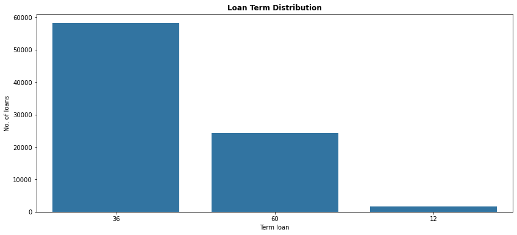

## Percentage of Homeowners

> The visualization below shows the percentage of borrowers who are homeowners and who are not homeowners.

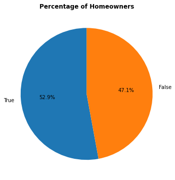

## Homeowner and Prosper Rating

> Does homeowner status influences the Prosper Rating?  
> The visualization shows how high Prosper Rating have many homeowners than non-homeowners whiles  
> low Prosper Rating have many non-homeowners than homeowners.

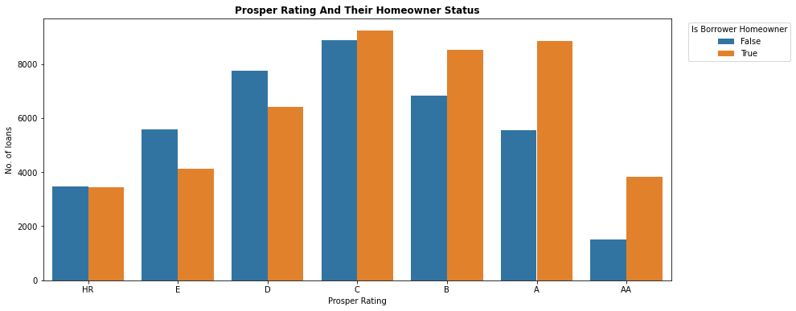

## No. of Loans Across the Year

> How has the number of loans increased from pre 2010 to 2014?  
> Which loan terms has increased drasticaly and remain the same?  
> The visualization below gives answers to these questions.

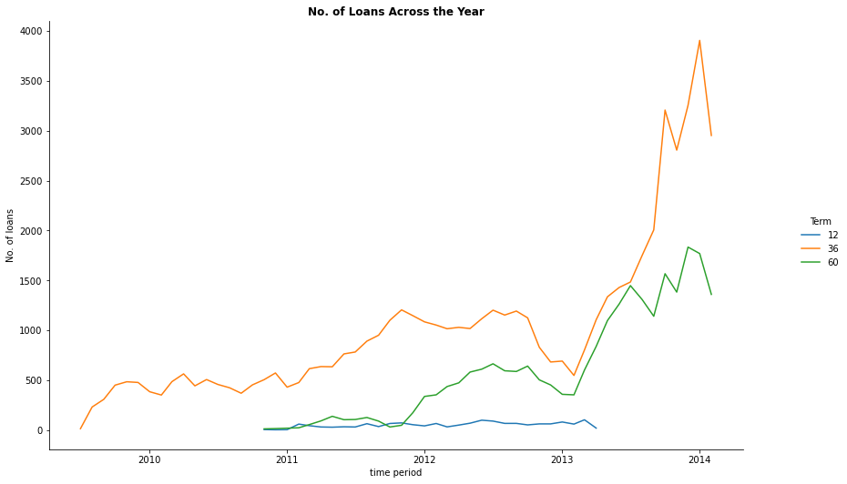

## Monthly Loan Payment vs Loan Amount

> Borrower's monthly loan payment are high for 12 loan term than the other two loan terms.  
> Loan amount above 25,000 are under 36 and 60 loan term with the 36 loan term having slight higher  
> monthly loan payment.

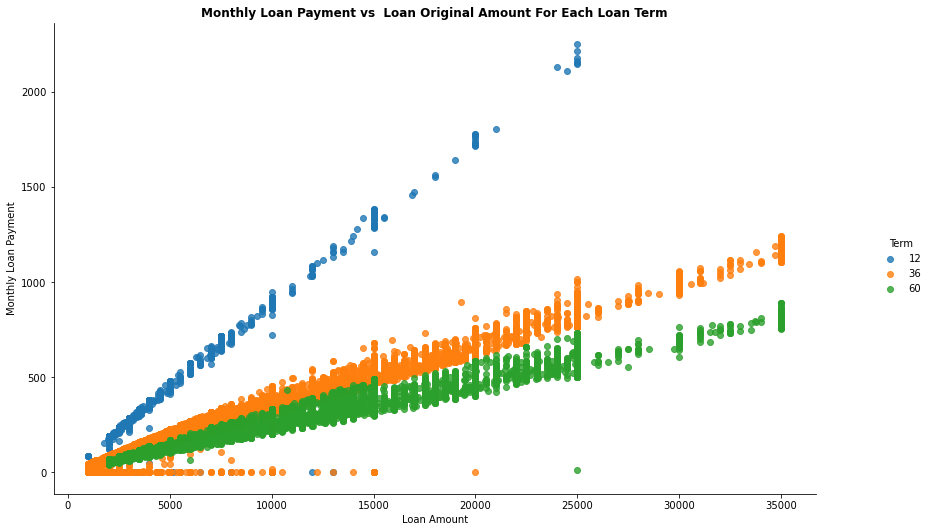